# main

## Overcooked Project

### Project Overview

- Implemented **PPO** and used **IPPO** for multi-agent reinforcement learning
  - Demonstrated competitive performance
- Focused on **generalization** on unseen layouts:
  - Trained agents on **5 training layouts**.

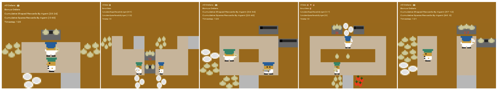

  - Evaluated generalization on **2 unseen layouts**.
- Built using **Jax/Flax** to achieve high throughput of acting/learning steps
  - Enabled feasible runtimes for hyperparameter optimization
- Conducted **Optuna** hyperparameter search to identify the optimal PPO hyperparameters, state encoding and architecture

### Sparse reward is not enough

- Reward is given **only when a soup is delivered**
- Soup delivery requires an orchestration of intermediate steps
  - **Problem**: it is difficults for agents to understand which intermediate actions contribute to the final delivery
- **Solution**: Implemented a **gymnasium wrapper** that uses `info` dictionary to do **reward shaping**
  - Babisits the agents to incentivize actions that increase the probability of delivery
- Early reward hacking is transient
  - The agent pair evnetually learns that delivering soups maximizes total reward.

## State Representation & Architectures

### Featurized Encoding

- **Hand-crafted features**
- Produces a **96-dimensional vector** (assumes 2 pots)
- Encodes:
  - Agent-centric features (position, direction)
  - Pot states
  - Relative distances to key entities
- **Problems**:
  - Spatial geometry and any information not captured by the hand-crafted features are discarded
  - Increasing the number of pots increases the feature dimension
- Processed via an **MLP**

### Lossless Encoding

- **Raw state**
- $H\times W\times C$ tensor:
  - $H, W$: spatial dimensions of the layout
  - $C$: each channel is a binary grid indicating presence/absence of an entity in a cell
- **Advantages**:
  - Preserves full spatial structure and state information
  - Layout-agnostic, supports variable entity numbers
- **Problem**: layouts may have different $H \times W$
  - **Solution**: zero-padding to the maximum size of all training layouts.
- Processed via **Nature-CNN-inspired architecture**

## Experiments & Results

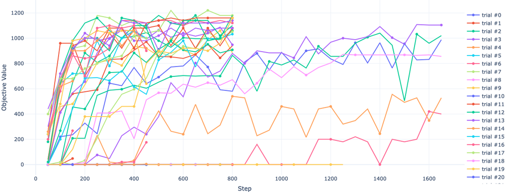

| Layout | Avg. Score |
| --- | --- |
| Cramped Room | 220 |
| Asymmetric Advantage | 460 |
| Coordination Ring | 260 |
| Forced Coordination | 260 |
| Counter Circuit | - |
| Cramped Tomato (Unseen) | 315 |
| 5x5 (Unseen) | - |

### Conclusion

- **Generalization emerges** when training on a diverse set of layouts
- **Featurized encoding** with *shared parameters* converges faster and obtain higher total reward¹
- **Fragility remains**:
  - Policies often “overfit” to specific training coordination patterns
  - Small layout changes can still break synchronization
- **Future work**:
  - Increase both the **variety** and **number** of training layouts through **procedural generation**

¹ **Total Reward**: Sum of cumulative rewards across all training layouts